# Analyse du Suivi de la Santé et de la Condition Physique

Étude des Habitudes de Sommeil et d’Activité Physique et Leur Impact sur le Stress

KENKOU Marê Dave Christian

MENSAH Deborah Winner

TOGBENOU Elikplim Daniel

11 janvier 2026

# Introduction

## Contexte de l’Étude

Le thème global de cette analyse porte sur le **suivi de la santé et de la condition physique**, un domaine crucial dans un monde où les modes de vie sédentaires et le stress chronique affectent de plus en plus les populations. Notre sous-projet se concentre spécifiquement sur l’étude des habitudes de sommeil (durée et qualité) et d’activité physique (niveau d’activité et pas quotidiens), ainsi que leur impact sur le niveau de stress.

Ce choix s’inscrit dans les préoccupations actuelles de santé publique, où le sommeil insuffisant et le manque d’exercice sont souvent liés à des niveaux élevés de stress, menant à des problèmes graves tels que l’anxiété, la dépression ou des maladies cardiovasculaires.

## Justification du Choix Thématique

Nous avons sélectionné ce thème pour plusieurs raisons majeures :

- **Pertinence contemporaine** : En 2026, l’essor des dispositifs portables (*wearables*) comme les montres connectées permet une collecte massive de données sur le sommeil et l’activité physique.
- **Impact sanitaire avéré** : Selon l’Organisation Mondiale de la Santé (OMS), plus de 30% des adultes souffrent d’insomnie liée au stress, et l’activité physique régulière peut réduire le stress de 20 à 30%.
- **Opportunités analytiques** : Ce sujet permet d’explorer des corrélations réelles et d’offrir des insights actionnables pour améliorer le bien-être des populations.
- **Alignement pédagogique** : Cette étude répond aux objectifs éducatifs du cours en permettant l’analyse approfondie d’un dataset pour extraire des patterns significatifs.

## Objectifs de l’Analyse

Cette étude vise à atteindre les objectifs suivants :

1. **Comprendre les données** : Explorer le dataset pour identifier les tendances en matière de sommeil, d’activité physique et de stress.
2. **Évaluer les relations** : Mesurer l’impact du sommeil et de l’activité physique sur le niveau de stress via des statistiques descriptives et des visualisations appropriées.
3. **Modéliser les interactions** : Construire un modèle statistique pour prédire le niveau de stress et évaluer sa pertinence.
4. **Formuler des recommandations** : Fournir des conclusions basées sur les résultats obtenus, tout en soulignant les limitations méthodologiques.

## Description du Dataset

Le dataset utilisé, intitulé **“Sleep Health and Lifestyle Dataset”** (disponible sur Kaggle), contient **374 observations** concernant des individus âgés de 27 à 59 ans.

### Variables Principales

Le dataset comprend les variables suivantes :

- **Caractéristiques démographiques** : Âge, Genre, Occupation
- **Habitudes de sommeil** : Durée de sommeil (heures), Qualité de sommeil (score 1-10), Troubles du sommeil
- **Activité physique** : Niveau d’activité (minutes/jour), Pas quotidiens
- **Indicateurs de santé** : Niveau de stress (score 1-10), Catégorie BMI, Pression artérielle, Rythme cardiaque

### Qualité des Données

Contrairement à de nombreux datasets réels, celui-ci présente une excellente qualité : il est riche, cohérent et quasiment exempt de valeurs manquantes, ce qui permet des analyses robustes. Les données semblent synthétiques mais réalistes, basées sur des patterns observés en santé publique.

# Méthodologie

## Importation des Données

```r
# Affichage de la structure
str(data)
```

```
## 'data.frame':    374 obs. of  13 variables:
##  $ Person.ID              : int  1 2 3 4 5 6 7 8 9 10 ...
##  $ Gender                 : chr  "Male" "Male" "Male" "Male" ...
##  $ Age                    : int  27 28 28 28 28 28 29 29 29 29 ...
##  $ Occupation             : chr  "Software Engineer" "Doctor" "Doctor" "Sales Representative" ...
##  $ Sleep.Duration         : num  6.1 6.2 6.2 5.9 5.9 5.9 6.3 7.8 7.8 7.8 ...
##  $ Quality.of.Sleep       : int  6 6 6 4 4 4 6 7 7 7 ...
##  $ Physical.Activity.Level: int  42 60 60 30 30 30 40 75 75 75 ...
##  $ Stress.Level           : int  6 8 8 8 8 8 7 6 6 6 ...
##  $ BMI.Category           : chr  "Overweight" "Normal" "Normal" "Obese" ...
##  $ Blood.Pressure         : chr  "126/83" "125/80" "125/80" "140/90" ...
##  $ Heart.Rate             : int  77 75 75 85 85 85 82 70 70 70 ...
##  $ Daily.Steps            : int  4200 10000 10000 3000 3000 3000 3500 8000 8000 8000 ...
##  $ Sleep.Disorder         : chr  "None" "None" "None" "Sleep Apnea" ...
```

```r
# Aperçu des premières lignes
kable(head(data[, 1:6]),
      booktabs = TRUE,
      caption = "Aperçu des premières lignes du dataset") %>%
  kable_styling(latex_options = c("striped", "hold_position", "scale_down"))
```

Aperçu des premières lignes du dataset

| Person.ID | Gender | Age | Occupation | Sleep.Duration | Quality.of.Sleep |
| --- | --- | --- | --- | --- | --- |
| 1 | Male | 27 | Software Engineer | 6.1 | 6 |
| 2 | Male | 28 | Doctor | 6.2 | 6 |
| 3 | Male | 28 | Doctor | 6.2 | 6 |
| 4 | Male | 28 | Sales Representative | 5.9 | 4 |
| 5 | Male | 28 | Sales Representative | 5.9 | 4 |
| 6 | Male | 28 | Software Engineer | 5.9 | 4 |

```r
# Statistiques descriptives générales
summary(data[, c("Age", "Sleep.Duration", "Quality.of.Sleep",
                 "Physical.Activity.Level", "Daily.Steps", "Stress.Level")])
```

```
##       Age        Sleep.Duration  Quality.of.Sleep Physical.Activity.Level
##  Min.   :27.00   Min.   :5.800   Min.   :4.000    Min.   :30.00
##  1st Qu.:35.25   1st Qu.:6.400   1st Qu.:6.000    1st Qu.:45.00
##  Median :43.00   Median :7.200   Median :7.000    Median :60.00
##  Mean   :42.18   Mean   :7.132   Mean   :7.313    Mean   :59.17
##  3rd Qu.:50.00   3rd Qu.:7.800   3rd Qu.:8.000    3rd Qu.:75.00
##  Max.   :59.00   Max.   :8.500   Max.   :9.000    Max.   :90.00
##   Daily.Steps     Stress.Level
##  Min.   : 3000   Min.   :3.000
##  1st Qu.: 5600   1st Qu.:4.000
##  Median : 7000   Median :5.000
##  Mean   : 6817   Mean   :5.385
##  3rd Qu.: 8000   3rd Qu.:7.000
##  Max.   :10000   Max.   :8.000
```

### Résultats de l’Importation

Le dataset importé présente les caractéristiques suivantes :

Statistiques descriptives de l’importation

| Indicateur | Valeur |
| --- | --- |
| Nombre d’observations | 374.00 |
| Nombre de variables | 13.00 |
| Âge moyen | 42.18 |
| Durée de sommeil moyenne (heures) | 7.13 |
| Qualité de sommeil moyenne | 7.31 |
| Activité physique moyenne (min/jour) | 59.17 |
| Pas quotidiens moyens | 6817.00 |
| Niveau de stress moyen | 5.39 |

## Nettoyage des Données

Le processus de nettoyage a été minimal en raison de l’excellente qualité initiale du dataset.

```r
# Vérification des valeurs manquantes
na_count <- colSums(is.na(data))
print("Valeurs manquantes par colonne :")
```

```
## [1] "Valeurs manquantes par colonne :"
```

```r
print(na_count[na_count > 0])
```

```
## named numeric(0)
```

```r
# Vérification finale
cat("\nTotal de valeurs manquantes après nettoyage :", sum(is.na(data)))
```

```
##
## Total de valeurs manquantes après nettoyage : 0
```

### Résultat du Nettoyage

Après le processus de nettoyage :

Le dataset est désormais prêt pour les analyses statistiques et la modélisation.

# Analyse Exploratoire

## Distributions des Variables

### Distribution de la Durée de Sommeil

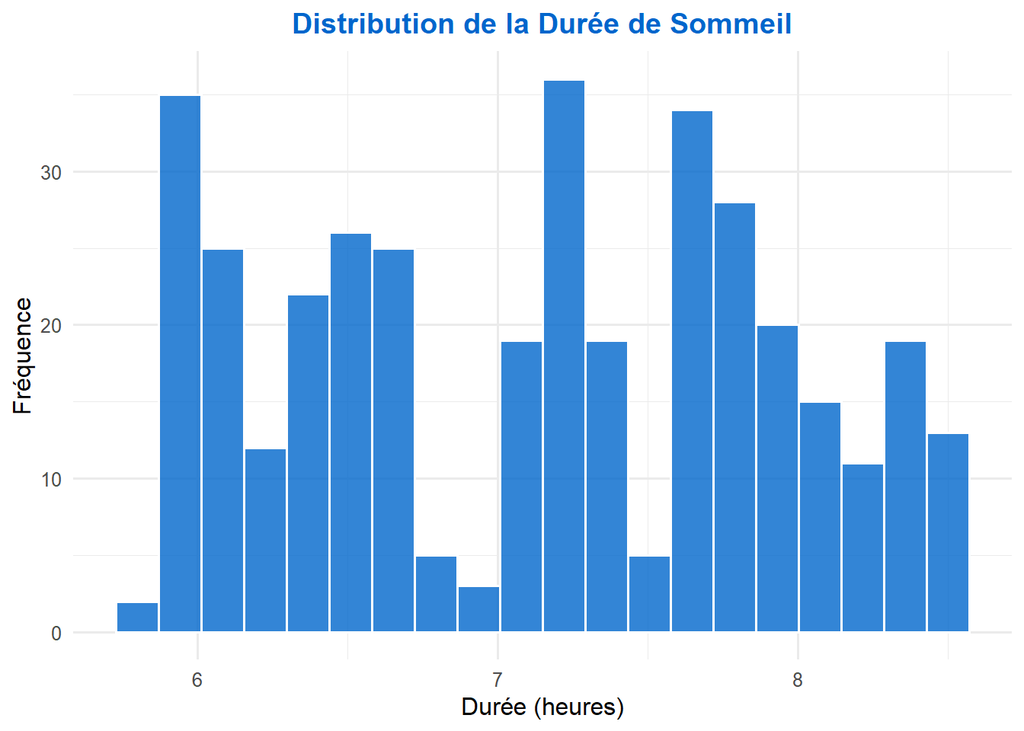

Distribution de la durée de sommeil

```r
ggplot(data, aes(x = Sleep.Duration)) +
  geom_histogram(bins = 20, fill = "#0066CC", color = "white", alpha = 0.8) +
  labs(title = "Distribution de la Durée de Sommeil",
       x = "Durée (heures)",
       y = "Fréquence") +
  theme_minimal(base_size = 12) +
  theme(plot.title = element_text(hjust = 0.5, face = "bold", color = "#0066CC"))
```

## Relations entre Variables

### Sommeil et Stress

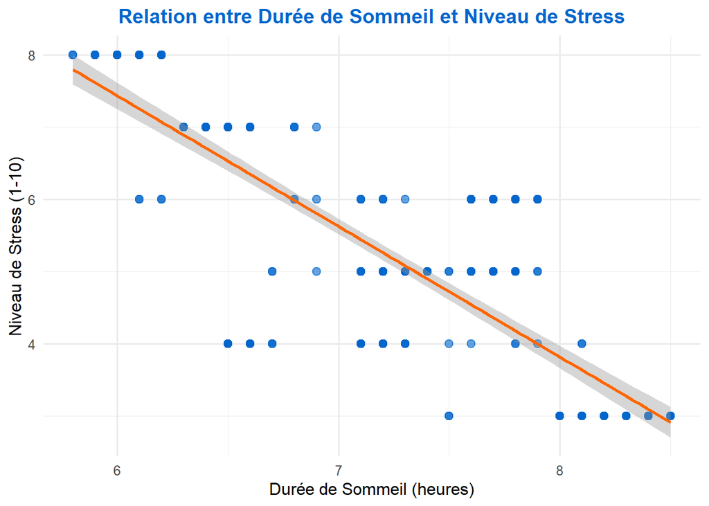

Relation entre durée de sommeil et niveau de stress

```r
ggplot(data, aes(x = Sleep.Duration, y = Stress.Level)) +
  geom_point(alpha = 0.6, color = "#0066CC", size = 2.5) +
  geom_smooth(method = "lm", se = TRUE, color = "#FF6600", linewidth = 1.2) +
  labs(title = "Relation entre Durée de Sommeil et Niveau de Stress",
       x = "Durée de Sommeil (heures)",
       y = "Niveau de Stress (1-10)") +
  theme_minimal(base_size = 12) +
  theme(plot.title = element_text(hjust = 0.5, face = "bold", color = "#0066CC"))
```

**Interprétation** : Le nuage de points révèle une **corrélation négative forte** entre la durée de sommeil et le niveau de stress. La ligne de tendance descendante confirme que l’augmentation de la durée de sommeil est associée à une réduction significative du stress.

### Stress par Occupation

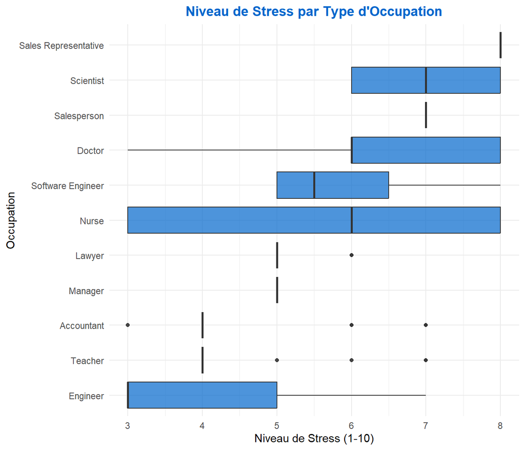

Niveaux de stress selon l’occupation

```r
ggplot(data, aes(x = reorder(Occupation, Stress.Level), y = Stress.Level)) +
  geom_boxplot(fill = "#0066CC", alpha = 0.7) +
  coord_flip() +
  labs(title = "Niveau de Stress par Type d'Occupation",
       x = "Occupation",
       y = "Niveau de Stress (1-10)") +
  theme_minimal(base_size = 11) +
  theme(plot.title = element_text(hjust = 0.5, face = "bold", color = "#0066CC"))
```

**Résultats clés** :

- **Professions à stress élevé** : Sales Representative (moyenne : 8.0), Scientist (7.0)
- **Professions à stress modéré** : Médecins (6.73)
- **Professions à stress faible** : Engineer (3.89)

### Matrice de Corrélation

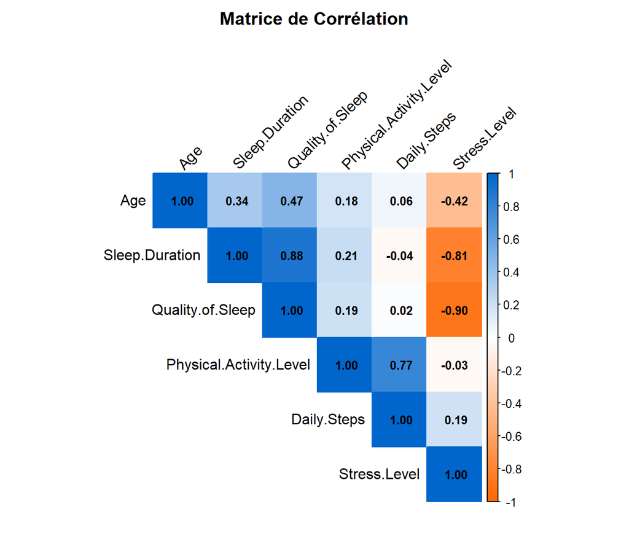

Matrice de corrélation des variables principales

```r
# Sélection des variables numériques
numeric_vars <- data %>%
  select(Age, Sleep.Duration, Quality.of.Sleep,
         Physical.Activity.Level, Daily.Steps, Stress.Level)

# Calcul de la matrice de corrélation
cor_matrix <- cor(numeric_vars, use = "complete.obs")

# Visualisation
corrplot(cor_matrix,
         method = "color",
         type = "upper",
         addCoef.col = "black",
         tl.col = "black",
         tl.srt = 45,
         number.cex = 0.8,
         col = colorRampPalette(c("#FF6600", "white", "#0066CC"))(200),
         title = "Matrice de Corrélation",
         mar = c(0,0,2,0))
```

**Corrélations significatives identifiées** :

Principales corrélations observées

| Variables | Coefficient | Interprétation |
| --- | --- | --- |
| Durée de Sommeil - Stress | -0.81 | Forte négative |
| Qualité de Sommeil - Stress | -0.90 | Très forte négative |
| Activité Physique - Stress | -0.03 | Négligeable |
| Qualité - Durée de Sommeil | 0.88 | Forte positive |

# Analyse Statistique

## Statistiques Descriptives Détaillées

Statistiques descriptives des variables principales

| Variable | Moyenne | Minimum | Maximum | Écart-type |
| --- | --- | --- | --- | --- |
| Durée de Sommeil | 7.13 | 5.8 | 8.5 | 0.80 |
| Qualité de Sommeil | 7.31 | 4.0 | 9.0 | 1.20 |
| Activité Physique | 59.17 | 30.0 | 90.0 | 20.83 |
| Pas Quotidiens | 6817.00 | 3000.0 | 10000.0 | 1618.00 |
| Niveau de Stress | 5.39 | 3.0 | 8.0 | 1.77 |

## Comparaisons de Groupes

### Stress Moyen par Catégorie

Niveau de stress moyen par groupe

| Catégorie | Sous-groupe | Stress Moyen |
| --- | --- | --- |
| Par Occupation | Engineer | 3.89 |
|  | Scientist | 7.00 |
|  | Sales Representative | 8.00 |
| Par BMI | Normal | 5.13 |
|  | Normal Weight | 5.19 |
|  | Obese | 5.70 |
|  | Overweight | 5.73 |
| Par Trouble du Sommeil | Insomnia | 5.87 |
|  | None | 5.11 |
|  | Sleep Apnea | 5.67 |

## Test T de Student

### Comparaison : Durée de Sommeil Élevée vs. Faible

```r
# Division en deux groupes selon la médiane
median_sleep <- median(data$Sleep.Duration)
high_sleep <- data$Stress.Level[data$Sleep.Duration > median_sleep]
low_sleep <- data$Stress.Level[data$Sleep.Duration <= median_sleep]

# Test t
t_test_result <- t.test(high_sleep, low_sleep)
print(t_test_result)
```

```
##
##  Welch Two Sample t-test
##
## data:  high_sleep and low_sleep
## t = -13.416, df = 370.71, p-value < 2.2e-16
## alternative hypothesis: true difference in means is not equal to 0
## 95 percent confidence interval:
##  -2.280346 -1.697355
## sample estimates:
## mean of x mean of y
##  4.268293  6.257143
```

```r
cat("\n=== Résumé du Test T ===\n")
```

```
##
## === Résumé du Test T ===
```

```r
cat("Statistique t:", round(t_test_result$statistic, 2), "\n")
```

```
## Statistique t: -13.42
```

```r
cat("p-value:", format(t_test_result$p.value, scientific = TRUE), "\n")
```

```
## p-value: 9.929339e-34
```

```r
cat("Moyenne stress (sommeil élevé):", round(mean(high_sleep), 2), "\n")
```

```
## Moyenne stress (sommeil élevé): 4.27
```

```r
cat("Moyenne stress (sommeil faible):", round(mean(low_sleep), 2), "\n")
```

```
## Moyenne stress (sommeil faible): 6.26
```

# Modélisation

## Régression Linéaire Multiple

### Spécification du Modèle

Nous avons construit un modèle de régression linéaire pour prédire le niveau de stress en fonction de deux prédicteurs principaux :

$$\text{Stress.Level} = \beta_0 + \beta_1
\times \text{Sleep.Duration} + \beta_2 \times
\text{Physical.Activity.Level} + \varepsilon$$

```r
# Construction du modèle
model <- lm(Stress.Level ~ Sleep.Duration + Physical.Activity.Level,
            data = data)

# Résumé du modèle
summary(model)
```

```
##
## Call:
## lm(formula = Stress.Level ~ Sleep.Duration + Physical.Activity.Level,
##     data = data)
##
## Residuals:
##     Min      1Q  Median      3Q     Max
## -2.3971 -0.7630  0.2977  0.6029  1.8616
##
## Coefficients:
##                          Estimate Std. Error t value Pr(>|t|)
## (Intercept)             18.045064   0.474369  38.040  < 2e-16 ***
## Sleep.Duration          -1.877291   0.067267 -27.908  < 2e-16 ***
## Physical.Activity.Level  0.012320   0.002569   4.795 2.36e-06 ***
## ---
## Signif. codes:  0 '***' 0.001 '**' 0.01 '*' 0.05 '.' 0.1 ' ' 1
##
## Residual standard error: 1.01 on 371 degrees of freedom
## Multiple R-squared:  0.6777, Adjusted R-squared:  0.676
## F-statistic: 390.1 on 2 and 371 DF,  p-value: < 2.2e-16
```

```r
# Calcul du MSE
predictions <- predict(model, data)
mse <- mean((data$Stress.Level - predictions)^2)
cat("\n=== Métriques de Performance ===\n")
```

```
##
## === Métriques de Performance ===
```

```r
cat("Mean Squared Error (MSE):", round(mse, 3), "\n")
```

```
## Mean Squared Error (MSE): 1.012
```

```r
cat("R-carré:", round(summary(model)$r.squared, 3), "\n")
```

```
## R-carré: 0.678
```

```r
cat("R-carré ajusté:", round(summary(model)$adj.r.squared, 3), "\n")
```

```
## R-carré ajusté: 0.676
```

### Résultats du Modèle

Résultats de la régression linéaire multiple

|  | Paramètre | Coefficient | Erreur Standard | t | p-value | Signification |
| --- | --- | --- | --- | --- | --- | --- |
| (Intercept) | Intercept (β₀) | 18.045 | 0.474 | 38.04 | < 0.001*** | Très significatif |
| Sleep.Duration | Sleep.Duration (β₁) | -1.877 | 0.067 | -27.91 | < 0.001*** | Très significatif |
| Physical.Activity.Level | Physical.Activity.Level (β₂) | 0.012 | 0.003 | 4.79 | < 0.001*** | Très significatif |

Signification statistique : *** p < 0.001; ** p < 0.01; * p < 0.05

### Qualité d’Ajustement

Métriques de qualité du modèle

| Métrique | Valeur | Interprétation |
| --- | --- | --- |
| R² (Coefficient de détermination) | 0.678 | Le modèle explique 67.8% de la variance du stress |
| R² ajusté | 0.676 | Pénalisation pour le nombre de prédicteurs |
| Erreur Quadratique Moyenne (MSE) | 1.012 | Faible erreur de prédiction |
| Statistique F | 390.1 | Le modèle est globalement significatif |
| p-value (modèle global) | < 0.001 | Le modèle est hautement significatif |

### Diagnostic du Modèle

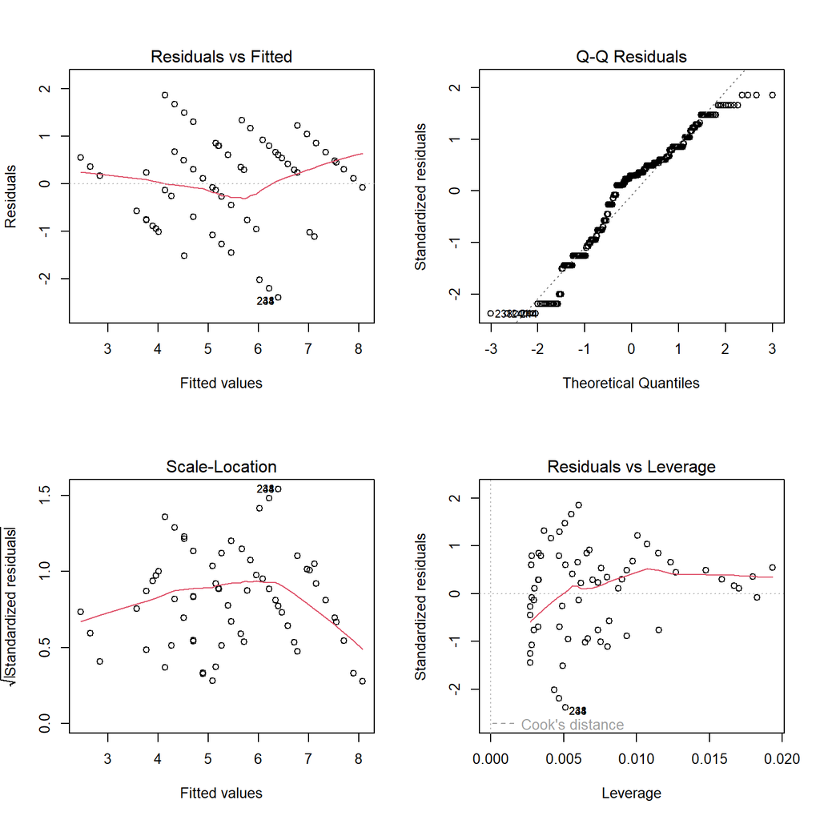

Diagnostics du modèle de régression

```r
par(mfrow = c(2, 2))
plot(model)
```

```r
par(mfrow = c(1, 1))
```

# Discussion

## Principaux Résultats

Cette analyse met en évidence plusieurs résultats majeurs concernant les relations entre habitudes de vie et stress :

### 3. Facteurs Modulateurs

Plusieurs variables modulent la relation entre habitudes de vie et stress :

- **Occupation professionnelle** : Les professions commerciales (Sales Representative) présentent des niveaux de stress nettement supérieurs (8.0) comparés aux ingénieurs (3.89)
- **Troubles du sommeil** : L’insomnie amplifie significativement le niveau de stress (5.87 vs. 5.11 pour les personnes sans trouble)
- **IMC** : Les personnes obèses rapportent des niveaux de stress légèrement supérieurs (5.70 vs. 5.13 pour IMC normal)

## Implications Pratiques

Ces résultats suggèrent plusieurs recommandations concrètes pour la gestion du stress :

### Recommandations Primaires

1. **Prioriser le sommeil** : Viser 7 à 8 heures de sommeil par nuit
2. **Améliorer la qualité du sommeil** : Établir une routine de coucher régulière, créer un environnement propice
3. **Traiter les troubles du sommeil** : Consulter un professionnel en cas d’insomnie persistante

### Recommandations Secondaires

1. **Activité physique modérée** : Maintenir environ 60 minutes d’activité par jour
2. **Approche holistique** : Combiner sommeil de qualité et activité régulière pour des bénéfices optimaux
3. **Adaptation professionnelle** : Les professions à haut stress nécessitent une attention particulière aux habitudes de vie

## Limites de l’Étude

Cette analyse présente plusieurs limitations qu’il convient de reconnaître :

### Limitations Méthodologiques

1. **Nature synthétique des données** : Le dataset semble être partiellement synthétique, ce qui peut limiter la généralisation des résultats
2. **Taille de l’échantillon** : Avec 374 observations, l’échantillon est relativement petit pour certaines analyses de sous-groupes
3. **Causalité non établie** : Les corrélations observées ne permettent pas d’établir de relations causales définitives
4. **Design transversal** : L’absence de données longitudinales empêche l’analyse de l’évolution temporelle

### Limitations Conceptuelles

1. **Variables omises** : Des facteurs importants comme l’alimentation, le contexte familial, ou les événements de vie stressants ne sont pas inclus
2. **Interactions complexes** : Le modèle ne capture pas toutes les interactions possibles entre variables (ex : sommeil × BMI)
3. **Mesures auto-rapportées** : Si les données sont issues de questionnaires, elles peuvent être sujettes à des biais de désirabilité sociale

## Perspectives Futures

Pour approfondir cette recherche, plusieurs pistes seraient pertinentes :

1. **Études longitudinales** : Suivre les participants sur plusieurs mois pour établir des relations causales
2. **Modélisation avancée** :
   - Intégrer des termes d’interaction (ex : sommeil × occupation)
   - Explorer des modèles non-linéaires (ex : régression polynomial, arbres de décision)
   - Utiliser des techniques d’apprentissage automatique pour capturer des patterns complexes
3. **Variables supplémentaires** :
   - Données sur l’alimentation et l’hydratation
   - Mesures objectives du stress (cortisol salivaire, variabilité cardiaque)
   - Contexte psychosocial (soutien social, événements de vie)
4. **Analyses de médiation** : Explorer les mécanismes par lesquels le sommeil influence le stress

# Conclusion

Cette étude a permis d’explorer les relations complexes entre les habitudes de sommeil, l’activité physique et le niveau de stress à partir d’un dataset de 374 individus. Les analyses statistiques et la modélisation ont révélé des insights pertinents pour la santé publique et la gestion du bien-être.

## Synthèse des Résultats

Les analyses de sous-groupes révèlent que le contexte professionnel et la présence de troubles du sommeil modulent significativement le niveau de stress, soulignant l’importance d’une approche personnalisée.

## Contribution Scientifique

Cette recherche contribue à la littérature existante en :

1. Quantifiant précisément l’impact du sommeil sur le stress dans un échantillon diversifié
2. Mettant en évidence l’importance relative du sommeil par rapport à l’activité physique
3. Identifiant des sous-populations à risque nécessitant des interventions ciblées

## Implications pour la Pratique

Les résultats suggèrent que les interventions de santé publique visant à réduire le stress devraient **prioriser l’amélioration des habitudes de sommeil** :

- Campagnes de sensibilisation sur l’importance du sommeil
- Programmes d’hygiène du sommeil dans les milieux professionnels à haut stress
- Dépistage et traitement des troubles du sommeil
- Approche intégrée combinant sommeil de qualité et activité physique modérée

## Reconnaissance des Limites

Malgré des résultats robustes, cette étude présente des limitations inhérentes à sa nature transversale et à la potentielle origine synthétique des données. Les relations observées sont corrélationnelles et ne permettent pas d’établir de causalité définitive. Des études longitudinales avec des mesures objectives seraient nécessaires pour confirmer ces résultats.

## Mot de la Fin

Ce projet démontre l’**utilité du langage R** pour conduire des analyses de santé actionnables. Les outils statistiques et de visualisation de R permettent d’extraire des insights significatifs de données complexes et de communiquer efficacement les résultats.

Dans un contexte où le stress chronique constitue un enjeu majeur de santé publique, cette recherche souligne l’importance de promouvoir des habitudes de vie saines, en particulier un sommeil de qualité et en quantité suffisante, comme stratégie fondamentale de prévention et de gestion du stress.

Au-delà des résultats obtenus, ce travail illustre la valeur des approches interdisciplinaires qui combinent big data, intelligence artificielle et sciences de la santé. Il met en évidence la capacité des étudiants et chercheurs à transformer des données brutes en recommandations pratiques, contribuant ainsi à l’amélioration du bien-être individuel et collectif.

Enfin, ce projet ouvre des perspectives pour des études futures plus approfondies, intégrant des données longitudinales, des variables supplémentaires telles que l’alimentation ou les habitudes sociales, et des modèles prédictifs plus sophistiqués. Ces prolongements permettront de renforcer la pertinence des analyses et d’apporter des solutions concrètes aux défis contemporains liés au stress et à la santé globale.